# BMI206 Project Part 1

Wanjun Gu, Ashvin Ravi, Reet Mishra

2023-10-24

## Data acquisition

Paper Title: **Global reference mapping of human transcription factor footprints** Paper reference: Vierstra, J. et al. Global reference mapping of human transcription factor footprints. Nature 583, 729–736 (2020)

Data is downloaded from: https://static-content.springer.com/esm/art%3A10.1038%2Fs41586-020-2528-x/MediaObjects/41586_2020_2528_MOESM4_ESM.xlsx

## Load libraries

```r
suppressPackageStartupMessages({
  library(dplyr)
  library(data.table)
  library(readxl)
})
```

## Load data

```r
cluster = read_excel("supp table 2.xlsx", sheet = "Archetype clusters")
motifs = read_excel("supp table 2.xlsx", sheet = "Motifs")

d = left_join(cluster, motifs, by = "Cluster_ID")
```

## Summary of the dataset

```r
glimpse(d)
```

```
## Rows: 2,174
## Columns: 15
## $ Cluster_ID           <dbl> 284, 284, 284, 139, 139, 54, 54, 54, 54, 54, 54, …
## $ Name                 <chr> "AHR", "AHR", "AHR", "AIRE", "AIRE", "AP1/1", "AP…
## $ DBD                  <chr> "bHLH", "bHLH", "bHLH", "not_classified", "not_cl…
## $ Seed_motif           <chr> "AHR_HUMAN.H11MO.0.B", "AHR_HUMAN.H11MO.0.B", "AH…
## $ Total_width          <dbl> 9, 9, 9, 18, 18, 17, 17, 17, 17, 17, 17, 17, 17, …
## $ Consensus_left       <dbl> 2, 2, 2, 2, 2, 4, 4, 4, 4, 4, 4, 4, 4, 4, 4, 4, 4…
## $ Consensus_right      <dbl> 8, 8, 8, 17, 17, 12, 12, 12, 12, 12, 12, 12, 12, …
## $ Cluster_size         <dbl> 3, 3, 3, 2, 2, 41, 41, 41, 41, 41, 41, 41, 41, 41…
## $ Motif                <chr> "AHR_HUMAN.H11MO.0.B", "AHR_MOUSE.H11MO.0.B", "Ah…
## $ Database             <chr> "HOCOMOCO_v11", "HOCOMOCO_v11", "Jaspar2018", "HO…
## $ Consensus            <chr> "GTTGCGTGC", "GTTGCGTGC", "TGCGTG", "ATTGGTTTTATT…
## $ Relative_orientation <chr> "+", "+", "+", "+", "+", "+", "+", "+", "+", "+",…
## $ Width                <dbl> 9, 9, 6, 18, 18, 9, 9, 9, 9, 11, 11, 10, 11, 11, …
## $ Left_offset          <dbl> 0, 0, 2, 0, 0, 3, 3, 3, 3, 2, 1, 2, 2, 2, 2, 1, 3…
## $ Right_offset         <dbl> 0, 0, 1, 0, 0, 5, 5, 5, 5, 4, 5, 5, 4, 4, 4, 4, 5…
```

## Column description

| Column descriptions |
| --- |
| Cluster_ID: Motif cluster number |
| Name: Cluster name (motif, DBD or individual TF gene names) |
| DBD: DNA-binding domain family |
| Seed_motif: Motif to which other cluster members are aligned |
| Total_width: Total with of all aligned motifs within cluster |
| Consensus_left: Left boundary of archetype motif |
| Consensus_right: Right boundary of archetype motif |
| Cluster_size: Number of motifs in cluster |
| Motif: Motif model name |
| Database: Source of motif model |
| Consensus: Model consensus sequence |
| Relative_orientation: Relative orientation of motof model to cluster seed motif |
| Width: Motif model width |
| Left_offset: Offset relative to left coordinate of full cluster width |
| Right_offset: Offset relative to right coordinate of full cluster width |

```r
summary(d)
```

```
##    Cluster_ID         Name               DBD             Seed_motif
##  Min.   :  1.00   Length:2174        Length:2174        Length:2174
##  1st Qu.: 41.00   Class :character   Class :character   Class :character
##  Median : 74.00   Mode  :character   Mode  :character   Mode  :character
##  Mean   : 96.07
##  3rd Qu.:144.00
##  Max.   :286.00
##   Total_width    Consensus_left   Consensus_right  Cluster_size
##  Min.   : 6.00   Min.   : 0.000   Min.   : 6.0    Min.   :  1.00
##  1st Qu.:15.00   1st Qu.: 2.000   1st Qu.:12.0    1st Qu.:  9.00
##  Median :18.00   Median : 3.000   Median :15.0    Median : 18.00
##  Mean   :19.28   Mean   : 3.784   Mean   :15.3    Mean   : 35.18
##  3rd Qu.:23.00   3rd Qu.: 5.000   3rd Qu.:17.0    3rd Qu.: 34.00
##  Max.   :35.00   Max.   :10.000   Max.   :29.0    Max.   :186.00
##     Motif             Database          Consensus         Relative_orientation
##  Length:2174        Length:2174        Length:2174        Length:2174
##  Class :character   Class :character   Class :character   Class :character
##  Mode  :character   Mode  :character   Mode  :character   Mode  :character
##
##
##
##      Width        Left_offset      Right_offset
##  Min.   : 6.00   Min.   : 0.000   Min.   : 0.000
##  1st Qu.:10.00   1st Qu.: 0.000   1st Qu.: 0.000
##  Median :12.00   Median : 2.000   Median : 2.000
##  Mean   :12.85   Mean   : 3.129   Mean   : 3.294
##  3rd Qu.:15.00   3rd Qu.: 5.000   3rd Qu.: 5.000
##  Max.   :25.00   Max.   :15.000   Max.   :14.000
```

In this dataset, there are **2,174** motifs grouped into **286** clusters. For each motif/cluster, there are measurements of motif total width (*numeric*), offset relative to left/right coordinate of full cluster width (*numeric*), as well as their relative_orientations (*cetagorical/binary*). Here we showed the distribution of the length of Motifs

Cognate transcription factors (TFs) can be assigned to footprints on the basis of matching consensus sequences, enabling the TF-focused analysis of gene regulation and regulatory networks10 and of the evolution of regulatory factor binding patterns

Consensus footprints were on average 16bp wide (middle 95%: 7–44 bp; 90%: 7–36bp; 50%: 9–21bp) and were distributed across all classes of DHS, albeit with enrichment in promoter-proximal elements owing to their generally elevated cleavage density (Extended Data Fig.3b, c)

## Distribution of the length of Motifs

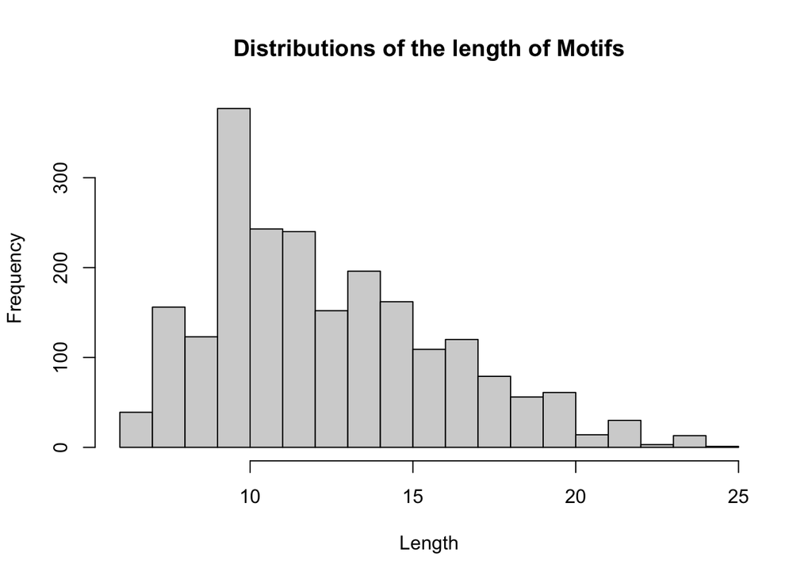

```r
hist(d$Width, main = "Distributions of the length of Motifs",
     xlab = "Length", breaks = 25)
```